# network

# Chargement des bibliothèques

# Chargement des données

```r
data<- readLines("Frank Herbert - Dune.txt_clean")
head(data)
```

```
## [1] "= = = = = = "
## [2] ""
## [3] "A beginning is the time for taking the most delicate care that the balances are correct. This every sister of the Bene Gesserit knows. To begin your study of the life of Muad'Dib, then, take care that you first place him in his time: born in the 57th year of the Padishah Emperor, Shaddam IV.…
## [4] "-from \"Manual of Muad'Dib\" by the Princess Irulan"
## [5] ""
## [6] "    In the week before their departure to Arrakis, when all the final scurrying about had reached a nearly unbearable frenzy, an old crone came to visit the mother of the boy, Paul."
```

# Phrase per ligne

```r
phrase <- c()

#stock les phrases
for (i in data){
  phrase <- c(phrase, unlist(str_split(i, "\\. \"|\\.\"|[.][:space:]+(?=[:upper:])")))
}

phrase <- gsub("\\\"|[.]","",phrase)

data_split <- data.frame(line = 1:length(phrase),text = phrase, stringsAsFactors = FALSE)

head(data_split)
```

|  | line | text |
| --- | --- | --- |
| 1 | 1 | = = = = = = |
| 2 | 2 |  |
| 3 | 3 | A beginning is the time for taking the most delicate care that the balances are correct |
| 4 | 4 | This every sister of the Bene Gesserit knows |
| 5 | 5 | To begin your study of the life of Muad'Dib, then, take care that you first place him in his time: born in the 57th year of the Padishah Emperor, Shaddam IV |
| 6 | 6 | And take the most special care that you locate Muad'Dib in his place: the planet Arrakis |

# Ajouter colonne “chapitre” pour chaque ligne

```r
#data_split[data_split$line == "= = = = = =",]
data_split$chapitre <- cumsum(as.integer(data_split$text=="= = = = = ="))+1
dim(data_split)
```

```
## [1] 19073     3
```

```r
head(data_split)
```

|  | line | text | chapitre |
| --- | --- | --- | --- |
| 1 | 1 | = = = = = = | 1 |
| 2 | 2 |  | 1 |
| 3 | 3 | A beginning is the time for taking the most delicate care that the balances are correct | 1 |
| 4 | 4 | This every sister of the Bene Gesserit knows | 1 |
| 5 | 5 | To begin your study of the life of Muad'Dib, then, take care that you first place him in his time: born in the 57th year of the Padishah Emperor, Shaddam IV | 1 |
| 6 | 6 | And take the most special care that you locate Muad'Dib in his place: the planet Arrakis | 1 |

# Transformation du jeu de données pour faire apparaître le numéro des chapitres

```r
#le dataframe qui ne contient pas de ligne '= = = = = = "
data_chapter <- data_split[-which(data_split$text=="= = = = = ="),]
#nombre de ligne pour chaque ligne
table(data_chapter$chapitre)
```

```
##
##   1   2   3   4   5   6   7   8   9  10  11  12  13  14  15  16  17  18
## 458 363 275 393 405 436 354 138 309 178 622 212 129 888 736 511 175 447
##  19  20  21  22  23  24  25  26  27  28  29  30  31  32  33  34  35  36
## 105 512 482   4 143 474 483 536 527 286 314 233 412 302 474 468 645 337
##  37  38  39  40  41  42  43  44  45  46  47  48
## 461   4 342 282 788 279 651 464 391 366 353 878
```

En observant la table de fréquence, chapitre 22 et 38 ne contient que 4 lignes.

```r
data_chapter[which(data_chapter$chapitre %in% c(22,38)),]
```

|  | line | text | chapitre |
| --- | --- | --- | --- |
| 8150 | 8150 |  | 22 |
| 8151 | 8151 | Book Two | 22 |
| 8152 | 8152 | MUAD'DIB | 22 |
| 8153 | 8153 |  | 22 |
| 14265 | 14265 |  | 38 |
| 14266 | 14266 | Book Three | 38 |
| 14267 | 14267 | THE PROPHET | 38 |
| 14268 | 14268 |  | 38 |

En fait, ce sont des lignes qui séparent les différentes grandes parties du livre. Dune contient 3 grandes parties : Book 1 , Book 2 et Book 3.

## Ajouter les numéros de parties pour chaque ligne

```r
#récupérer les noms de chqpitres qui ne contiennent que 4 lignes
sep_partie <- as.integer(names(which(table(data_chapter$chapitre)==4)))
#ajouter la colonne "partie"
data_chapter$partie <- cumsum(as.integer(data_chapter$chapitre %in% sep_partie))+1
#ajuster la colonne "chapitre" car elle va être décalé en raison de la suppression des chapitres 22 et 38
data_chapter <- data_chapter[-which(data_chapter$chapitre %in% sep_partie),]
# data_clean : 46 facteurs
# data_brut : 51 facteurs
data_chapter$chapitre = as.factor(data_chapter$chapitre)
levels(data_chapter$chapitre) = as.factor(1:51)
data_chapter$partie = as.factor(data_chapter$partie)
levels(data_chapter$partie) = as.factor(1:3)

message("Nombre de ligne par chapitre")
```

```
## Nombre de ligne par chapitre
```

```r
table(data_chapter$chapitre)
```

```
##
##   1   2   3   4   5   6   7   8   9  10  11  12  13  14  15  16  17  18
## 458 363 275 393 405 436 354 138 309 178 622 212 129 888 736 511 175 447
##  19  20  21  22  23  24  25  26  27  28  29  30  31  32  33  34  35  36
## 105 512 482 143 474 483 536 527 286 314 233 412 302 474 468 645 337 461
##  37  38  39  40  41  42  43  44  45  46  47  48  49  50  51
## 342 282 788 279 651 464 391 366 353 878   0   0   0   0   0
```

```r
message("Nombre de ligne par partie")
```

```
## Nombre de ligne par partie
```

```r
table(data_chapter$partie)
```

```
##
##    1    2    3
## 8128 6095 4794
```

```r
head(data_chapter)
```

|  | line | text | chapitre | partie |
| --- | --- | --- | --- | --- |
| 1 | 1 | = = = = = = | 1 | 1 |
| 2 | 2 |  | 1 | 1 |
| 3 | 3 | A beginning is the time for taking the most delicate care that the balances are correct | 1 | 1 |
| 4 | 4 | This every sister of the Bene Gesserit knows | 1 | 1 |
| 5 | 5 | To begin your study of the life of Muad'Dib, then, take care that you first place him in his time: born in the 57th year of the Padishah Emperor, Shaddam IV | 1 | 1 |
| 6 | 6 | And take the most special care that you locate Muad'Dib in his place: the planet Arrakis | 1 | 1 |

## Enlever les lignes “= = = = = =” et vide

```r
data_chapter <- data_chapter[-which(data_chapter$text %in% c("= = = = = =",""," ")),]
data_chapter <- data_chapter[-1,]
data_chapter$line <- 1:nrow(data_chapter)
head(data_chapter)
```

|  | line | text | chapitre | partie |
| --- | --- | --- | --- | --- |
| 3 | 1 | A beginning is the time for taking the most delicate care that the balances are correct | 1 | 1 |
| 4 | 2 | This every sister of the Bene Gesserit knows | 1 | 1 |
| 5 | 3 | To begin your study of the life of Muad'Dib, then, take care that you first place him in his time: born in the 57th year of the Padishah Emperor, Shaddam IV | 1 | 1 |
| 6 | 4 | And take the most special care that you locate Muad'Dib in his place: the planet Arrakis | 1 | 1 |
| 7 | 5 | Do not be deceived by the fact that he was born on Caladan and lived his first fifteen years there | 1 | 1 |
| 8 | 6 | Arrakis, the planet known as Dune, is forever his place | 1 | 1 |

```r
lappend <- function (lst, ...){
  lst <- c(lst, list(...))
  return(lst)
}

add_in_dict <- function(data_dict){
  dict <- list()
  name <- c()

  for (row in 1:nrow(data_dict)){
    # print(row)

    synonym <- c()
    for (i in data_dict[row,]){

      if (!is.na(i)) {
        # print(i)
        synonym <- c(synonym,i)

      }
    }
    dict <- lappend(dict,synonym)
    name <- c(name,synonym[1])
  }

  names(dict) <- name
  # print(length(dict))
  # print(length(name))
  # print(name)
  return(dict)
}

add_in_dict2<- function(data_dict){
  dict <- list()
  name <- c()

  for (row in 1:nrow(data_dict)){
    # print(row)

    synonym <- c()
    for (i in data_dict[row,]){

      if (!is.na(i)) {
        # print(i)
        synonym <- c(synonym,gsub(" ","_",i))

      }
    }
    dict <- lappend(dict,synonym)
    name <- c(name,gsub("_"," ",synonym[1]))
  }

  names(dict) <- name
  # print(length(dict))
  # print(length(name))
  # print(name)
  return(dict)
}
#dictionaire des personnages
load("dictionaire_perso.RData")

character.dict <- add_in_dict(dict_perso[,-1])
character.dict
```

```
## $`paul atreides`
## [1] "paul atreides" "paul"
##
## $`duke leto atreides`
## [1] "duke leto atreides" "duke"               "leto"
##
## $`lady jessica`
## [1] "lady jessica" "jessica"
##
## $`alia atreides`
## [1] "alia atreides" "alia"
##
## $`thufir hawat`
## [1] "thufir hawat" "thufir"       "hawat"
##
## $`gurney halleck`
## [1] "gurney halleck" "gurney"         "halleck"
##
## $`duncan idaho`
## [1] "duncan idaho" "duncan"       "idaho"
##
## $`wellington yueh`
## [1] "wellington yueh" "wellington"      "yueh"
##
## $`baron vladimir harkonnen`
## [1] "baron vladimir harkonnen" "baron"
## [3] "vladimir"
##
## $`piter de vries`
## [1] "piter de vries" "piter"          "vries"
##
## $`feyd rautha`
## [1] "feyd rautha" "feyd"        "rautha"
##
## $`glossu beast rabban`
## [1] "glossu beast rabban" "glossu"              "beast"
## [4] "rabban"
##
## $`iakin nefud`
## [1] "iakin nefud" "iakin"       "nefud"
```

[output cut: 35 more lines]

```
##
## $jamis
## [1] "jamis" "jamis"
##
## $harah
## [1] "harah" "harah"
##
## $ramallo
## [1] "ramallo" "ramallo"
##
## $`esmar tuek`
## [1] "esmar tuek" "esmar"
##
## $`staban tuek`
## [1] "staban tuek" "staban"
```

```r
character.dict.underscore <- add_in_dict2(dict_perso[,-1])
```

Concatene les phrases par chapitre

```r
df_content_chap <- aggregate(text ~ chapitre, data = data_chapter, paste,collapse='. ')
```

Look up corpus

```r
library(quanteda)
toks <- tokens(tolower(df_content_chap$text),"word",remove_punct= TRUE) %>% tokens_compound(dictionary(character.dict))
DTM <-as.matrix(dfm(toks, dictionary = dictionary(character.dict)))
dim(DTM)
```

```
## [1] 46 28
```

Nombre de fois que chaque personnage apparaissent dans chaque chapitre

```r
pers_chap <- as.data.frame(as.table(DTM),stringsAsFactors = FALSE)
pers_chap$docs <- sapply(pers_chap$docs, function(x) gsub("text","",x))
pers_chap <- pers_chap[order(pers_chap$docs),]
pers_chap$docs <- as.integer(pers_chap$docs)
pers_chap$Freq <- as.integer(pers_chap$Freq)
row.names(pers_chap) <- NULL
head(pers_chap)
```

|  | docs | features | Freq |
| --- | --- | --- | --- |
| 1 | 1 | paul atreides | 36 |
| 2 | 1 | duke leto atreides | 5 |
| 3 | 1 | lady jessica | 25 |
| 4 | 1 | alia atreides | 0 |
| 5 | 1 | thufir hawat | 4 |
| 6 | 1 | gurney halleck | 0 |

Personnage par chapitre

```r
pers_chap_matrix <- t(DTM)
pers_chap_matrix[pers_chap_matrix > 0] <- 1
pers_chap_matrix
```

```
##                                     docs
## features                             text1 text2 text3 text4 text5 text6
##   paul atreides                          1     1     1     1     1     1
##   duke leto atreides                     1     1     1     1     1     1
##   lady jessica                           1     1     1     1     0     1
##   alia atreides                          0     0     0     0     0     0
##   thufir hawat                           1     1     0     1     1     1
##   gurney halleck                         0     0     1     1     1     0
##   duncan idaho                           0     0     0     1     1     1
##   wellington yueh                        1     1     0     1     1     1
##   baron vladimir harkonnen               0     1     0     0     0     0
##   piter de vries                         0     1     0     0     0     0
##   feyd rautha                            0     1     0     0     0     0
##   glossu beast rabban                    0     0     0     1     0     1
##   iakin nefud                            0     0     0     0     0     0
##   shaddam iv                             1     0     0     0     0     0
##   princess irulan                        1     1     1     1     1     1
##   count hasimir fenring                  0     1     0     0     1     0
##   reverend mother gaius helen mohiam     1     1     1     1     1     1
##   lady margot fenring                    0     1     0     0     0     0
##   the fremen                             0     0     0     1     1     1
##   stilgar                                0     0     0     0     0     0
##   chani                                  0     0     0     0     0     0
##   liet kynes                             0     1     0     0     1     0
##   mapes                                  0     0     0     0     0     1
##   jamis                                  0     0     0     0     0     0
##   harah                                  0     0     0     0     0     0
##   ramallo                                0     0     0     0     0     0
##   esmar tuek                             0     0     0     0     0     0
##   staban tuek                            0     0     0     0     0     0
##                                     docs
## features                             text7 text8 text9 text10 text11
##   paul atreides                          1     1     1      1      1
##   duke leto atreides                     1     0     1      1      1
##   lady jessica                           1     0     1      0      1
##   alia atreides                          0     0     0      0      0
##   thufir hawat                           1     0     1      1      1
##   gurney halleck                         0     0     1      1      1
##   duncan idaho                           0     0     1      0      1
##   wellington yueh                        1     1     1      0      0
```

[output cut: 215 more lines]

```
##   shaddam iv                              0      0      1      1      1
##   princess irulan                         1      1      1      1      1
##   count hasimir fenring                   0      0      1      1      1
##   reverend mother gaius helen mohiam      1      1      0      1      1
##   lady margot fenring                     0      0      0      0      1
##   the fremen                              1      1      1      1      1
##   stilgar                                 1      0      1      0      1
##   chani                                   1      1      0      0      1
##   liet kynes                              0      0      0      0      0
##   mapes                                   0      0      0      0      0
##   jamis                                   1      0      0      0      0
##   harah                                   0      1      0      0      0
##   ramallo                                 0      0      0      0      0
##   esmar tuek                              0      0      0      0      0
##   staban tuek                             0      0      0      0      0
```

Hiérachie clustering

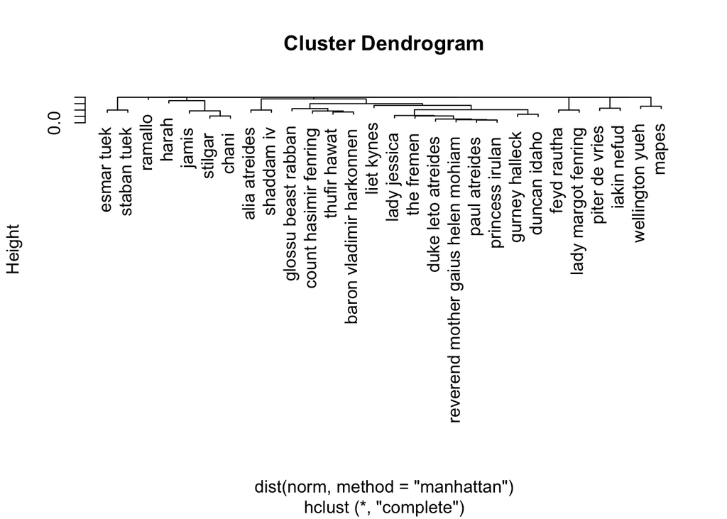

```r
norm <- pers_chap_matrix/ rowSums(pers_chap_matrix)

h <- hclust(dist(norm, method = "manhattan"))

plot(h)
```

```r
ordering <- h$labels[h$order]
ordering
```

```
##  [1] "esmar tuek"
##  [2] "staban tuek"
##  [3] "ramallo"
##  [4] "harah"
##  [5] "jamis"
##  [6] "stilgar"
##  [7] "chani"
##  [8] "alia atreides"
##  [9] "shaddam iv"
## [10] "glossu beast rabban"
## [11] "count hasimir fenring"
## [12] "thufir hawat"
## [13] "baron vladimir harkonnen"
## [14] "liet kynes"
## [15] "lady jessica"
## [16] "the fremen"
## [17] "duke leto atreides"
## [18] "reverend mother gaius helen mohiam"
## [19] "paul atreides"
## [20] "princess irulan"
## [21] "gurney halleck"
## [22] "duncan idaho"
## [23] "feyd rautha"
## [24] "lady margot fenring"
## [25] "piter de vries"
## [26] "iakin nefud"
## [27] "wellington yueh"
## [28] "mapes"
```

Diagramme pour observer les coocurrences des personnages dans chaque chapitre

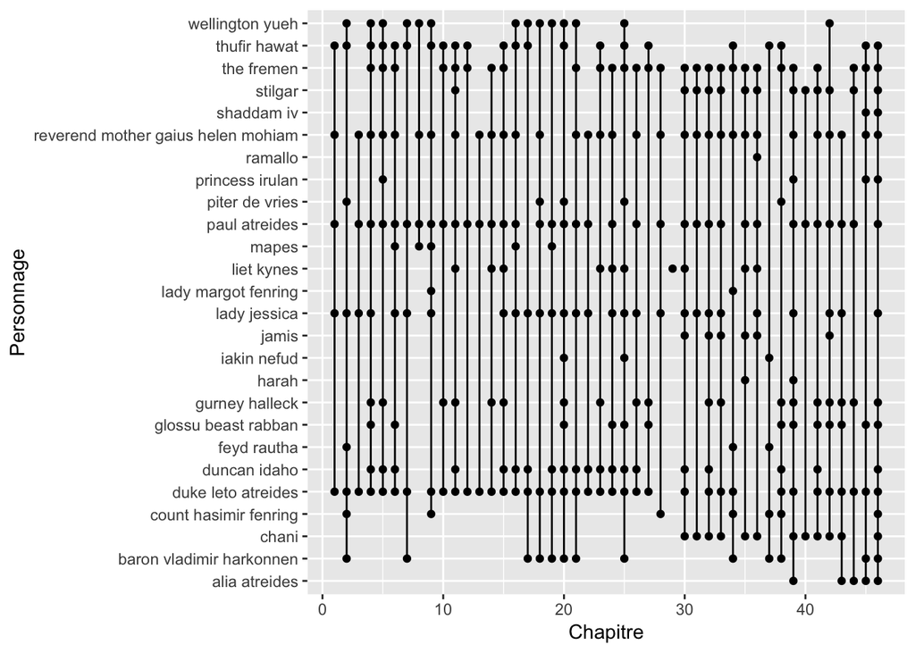

```r
chapters <- pers_chap %>%
    filter(Freq > 1) %>%        # scenes with > 1 character
    ungroup() %>%
    mutate(chap = as.numeric(factor(docs)),
           character = factor(features, levels = ordering))

ggplot(chapters, aes(chap, features)) +
    geom_point() +
    geom_path(aes(group = chap))+
    xlab("Chapitre")+
    ylab("Personnage")
```

Coocurrence matrice

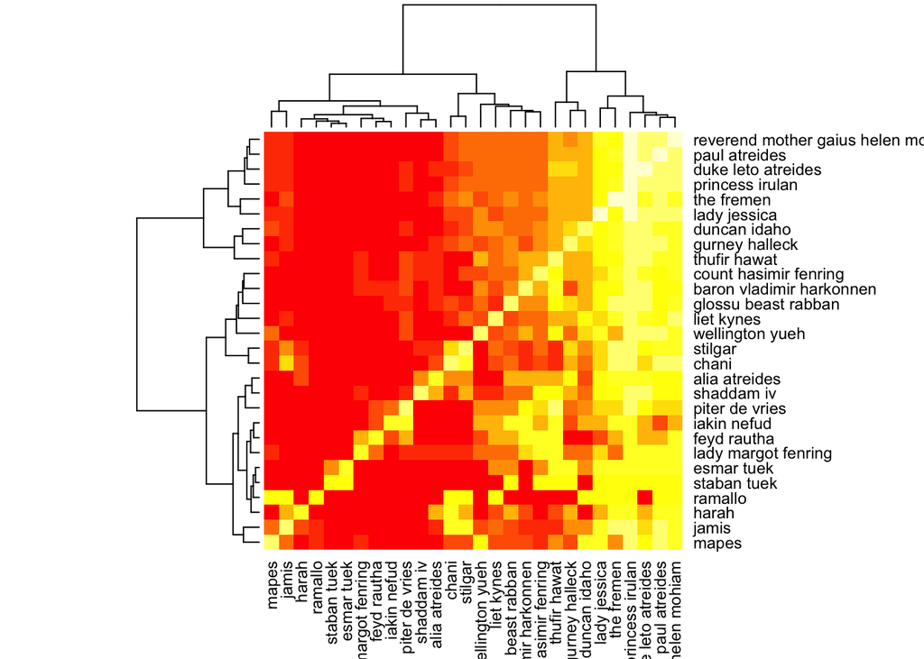

```r
cooccur <- pers_chap_matrix %*% t(pers_chap_matrix)

heatmap(cooccur)
```

Graphe coocurrence des personnages

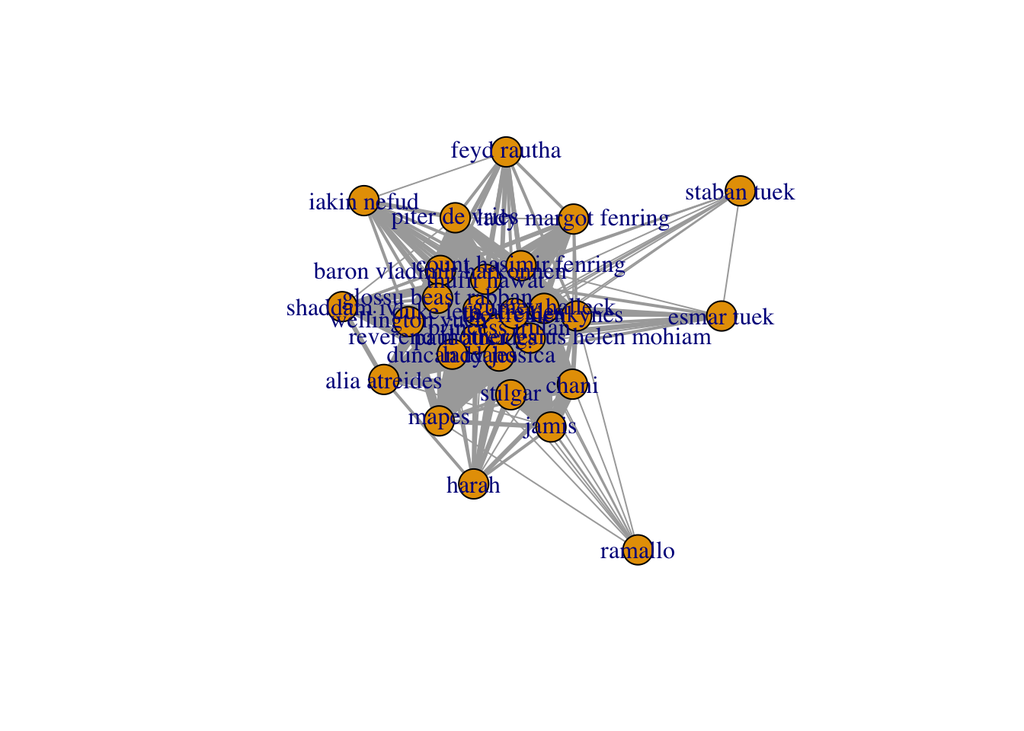

```r
library(igraph)
g <- graph.adjacency(cooccur, weighted = TRUE, mode = "undirected", diag = FALSE)
plot(g, edge.width = E(g)$weight)
```

Pourtant, il ne nous semble pas clair ce graph car dans chaque chapitre peut avoir plusieurs personnages qui apparaissent. Donc, il nous intéresse à voir les relations entre les personnages par chapitre.

Nous cherchons à identifier les index des nom des personnages puis appliquer un algo à calculer les poids entre les noms des personnages pour une fenêtre de 15 mots avant et après. Si on ne trouve pas le nom d’un personnage dans la fenêtre d’un autre personnage, c’est à dire il n’existe pas de relation entre ces 2 personnages dans ce chapitre car le poids égal à 0.

## Position des tokens trouvés

Trouver les positions des mots du vocabulaire dans le corpus puis calculer leur scores

```r
#fonction trouver les index des noms
find_position <- function(chap.ind, source, target){

  tok <- tokens(tolower(df_content_chap$text[chap.ind]),"word",remove_punct= TRUE) %>%
    tokens_compound(dictionary(character.dict[c(source,target)]))

  tok <- as.character(tok)

  return(list("s" = which(tok %in% character.dict.underscore[[source]]),
              "t" = which(tok %in% character.dict.underscore[[target]])))
}
```

Algo calculer score entre les personnage qui co ocurrent dans un chapitre

```r
# nb_chap <- as.integer(unique(df_content_chap$chapitre))

scores <- function (source.ind, target.ind){

  wordList <- list()
  upperBound <- length(source.ind)

  for (ind in source.ind){ #pour chaque index de source dans le corpus
    indlow <- ind-15
    indhigh <- ind+15
    x <- 0

    for (index in target.ind){
      x <- x + 1

      if (indlow <= index & index <= indhigh){
        wordList <- lappend(wordList,c(ind, index))
      }
    }

    wordUniqueList <- list()

    for (element in wordList){
      wordUniqueList <- lappend(wordUniqueList, element[[1]])
    }
  }

  scoreToShow <- round(length(wordUniqueList)/upperBound, 4)

  return (scoreToShow)
}
```

Trouver les combinaisons de source et target

```r
#les chapters ont des relations
mult <- pers_chap_matrix[, colSums(pers_chap_matrix) > 1]

# les noms source et target dans chaque chapitre
cooccurences <- lapply(seq_len(ncol(mult)), function(i) {

  mat <- as.matrix(mult[, i])
  mat <- as.matrix(mat[rowSums(mat) > 0, ])
  co <- mat %*% t(mat) %>%
    melt(varnames = c("Source", "Target"),value.name ="poids") %>%
      filter(Source != Target)#garder que des source et target different
  co <-  data.frame(lapply(co, as.character), stringsAsFactors=FALSE)
})
```

## Pour un simple graphe sans regroupement des groupe de personnage

Attention: Il prendre un peu de temps à exécuter poids.perso donc soit vous chargez directement le fichier .RData pour économiser le tepms, soit vous patientez lors de l’exécution de poids.perso

```r
#calculer le poids des relations par chapitre
#Attention: prendre un peu de temps à exécuter

# poids.perso <- lapply(seq_len(length(cooccurences)), function(i) {
#     cooccurences[[i]] %>%
#     rowwise() %>%
#       mutate(poids = scores(find_position(i,Source,Target)$s,
#                           find_position(i,Source,Target)$t)) %>%
#         filter(poids > 0)
# })

#à charger avec poids_per_chap.RData
load("poids_per_chap.RData")
message("Exemple pour chapitre 1; ")
```

```
## Exemple pour chapitre 1;
```

```r
poids.perso[[1]]
```

| Source | Target | poids |
| --- | --- | --- |
| lady jessica | paul atreides | 0.4000 |
| thufir hawat | paul atreides | 0.2500 |
| reverend mother gaius helen mohiam | paul atreides | 0.3800 |
| thufir hawat | duke leto atreides | 1.0000 |
| paul atreides | lady jessica | 0.2778 |
| reverend mother gaius helen mohiam | lady jessica | 0.3800 |
| paul atreides | thufir hawat | 0.0278 |
| duke leto atreides | thufir hawat | 0.8000 |
| paul atreides | reverend mother gaius helen mohiam | 0.5278 |
| lady jessica | reverend mother gaius helen mohiam | 0.7600 |

## Pour les graphes complexes (avec les groupes de personnages)

Attention: Il prendre un peu de temps à exécuter poids.perso.group donc soit vous chargez directement le fichier .RData pour économiser le tepms, soit vous patientez lors de l’exécution de poids.perso.group

```r
#attention : prendre un peu de temps à éxecuter

# poids.perso.group <- lapply(seq_len(length(poids.perso)), function(i) {
#     as.data.frame(poids.perso[[i]],stringAsFactor  = FALSE) %>%
#       left_join(personnage[,!(names(personnage) == "group")], by = c("Source" = "nom")) %>%
#         select(-Source) %>%
#         rename(Source = id) %>%
#       left_join(personnage[,!(names(personnage) == "group")], by = c("Target" = "nom")) %>%
#         select(-Target) %>%
#         rename(Target = id)
# })

#à charger avec poid_forceNet.RData
load("poids_forceNet.RData")
message("Exemple pour chapitre 1; ")
```

```
## Exemple pour chapitre 1;
```

```r
poids.perso.group[[1]]
```

| poids | Source | Target |
| --- | --- | --- |
| 0.4000 | 2 | 0 |
| 0.2500 | 4 | 0 |
| 0.3800 | 16 | 0 |
| 1.0000 | 4 | 1 |
| 0.2778 | 0 | 2 |
| 0.3800 | 16 | 2 |
| 0.0278 | 0 | 4 |
| 0.8000 | 1 | 4 |
| 0.5278 | 0 | 16 |
| 0.7600 | 2 | 16 |

Exemple pour Chapitre 1

```r
forceNetwork(Links = poids.perso.group[[1]],
                 Nodes = personnage,
                 Source = "Source",
                 Target = "Target",
                 NodeID ="nom",
                 Group = "group",
                 Value = "poids",
                 opacity = 1,
                 opacityNoHover = 2,
                 linkWidth = networkD3::JS("function(d) { return d.value*2; }"),
                 zoom = TRUE,
                 fontSize = 8,
                 legend = TRUE)
```

[interactive chart not shown]